# Colonial Past

Adela Sobotkova

2025-07-10

# Overall design

When comparing the effect of a certain event, e.g. colonialism, we need to inspect and statistically assess not only what happened with the affected countries, but also the non-affected countries. Inspection relates not only to the calculation and diachronic statistical overview of GDP, but consideration of other potentially impactful factors, such as colonial power, start century, and duration of colonization. It is important to articulate expectations behind these factors, such as with duration of colonial rule: one might hypothesize that colonizers with long experience would have experienced mismanagement and learned to manage their colonies reasonably well. Newcomers will be catching up and erring on the side of overreaction and brutality. First, it is good to generate visuals, describe the trends, answer the starting questions and develop new ones; inspect potential causalities and comment on outliers. Second, test trends emerging in the visuals for significance. Eyes and charts are seductive not not always ‘right’. How do you test what differences actually matter? Here, many tests can be administered, but we shall start with linear regression.

# Load libraries and create the data

```r
library(tidyverse)
library(gapminder)
library(sf)
gapminder
```

```
## # A tibble: 1,704 × 6
##    country     continent  year lifeExp      pop gdpPercap
##    <fct>       <fct>     <int>   <dbl>    <int>     <dbl>
##  1 Afghanistan Asia       1952    28.8  8425333      779.
##  2 Afghanistan Asia       1957    30.3  9240934      821.
##  3 Afghanistan Asia       1962    32.0 10267083      853.
##  4 Afghanistan Asia       1967    34.0 11537966      836.
##  5 Afghanistan Asia       1972    36.1 13079460      740.
##  6 Afghanistan Asia       1977    38.4 14880372      786.
##  7 Afghanistan Asia       1982    39.9 12881816      978.
##  8 Afghanistan Asia       1987    40.8 13867957      852.
##  9 Afghanistan Asia       1992    41.7 16317921      649.
## 10 Afghanistan Asia       1997    41.8 22227415      635.
## # ℹ 1,694 more rows
```

```r
# Create a dataframe for colonized countries
colonized_data <- data.frame(
  Country = c('India', 'Australia', 'Hong Kong, China','Canada', 'South Africa','Algeria', 'Vietnam', 'Morocco', 'Brazil', 'Mozambique',  'Indonesia', 'Suriname', 'Congo, Dem. Rep.', 'Rwanda', 'Namibia', 'Somalia', 'Libya', 'Eritrea', 'Philippines', 'Puerto Rico', 'Kazakhstan', 'Georgia', 'Moldova', 'Afghanistan', 'Tanzania',  'Czech Republic', 'Slovakia', 'Romania',  'Serbia', 'Bulgaria'),
  Colonial_Overlord = c('United Kingdom', 'United Kingdom','United Kingdom','United Kingdom', 'United Kingdom', 'France', 'France', 'France', 'Portugal', 'Portugal', 'Netherlands', 'Netherlands', 'Belgium','Belgium', 'Germany', 'Italy', 'Italy','Italy', 'United States', 'United States', 'Russia', 'Russia','Russia', 'United Kingdom', 'Germany', 'Austria', 'Austria','Austria', 'Turkey','Turkey' ),
  Years_of_Colonization = c(190, 132, 156, 108, 120, 132, 67, 44, 322, 477, 350, 235, 80, 40, 35, 36, 31, 62, 48, 126, 250, 108,103 ,80, 44,300, 500, 300, 350, 350 )
)

# Save the dataframe as CSV
#dir.create("data")
#write.csv(colonized_data, "data/colonized_countries.csv", row.names = FALSE)
```

Check other sources for Western and Asian imperialism for Africa and Asia and the Americas. Some examples are: https://www.reddit.com/media?url=https%3A%2F%2Fpreview.redd.it%2Flw1qqtmaxl841.png%3Fauto%3Dwebp%26s%3D45a5eee700205f4d24f36c1f116a84a60233dae6 https://accordingtophillips.weebly.com/uploads/8/1/8/3/81833274/imperialism-in-asia-1900_orig.jpg https://s3.amazonaws.com/s3.timetoast.com/public/uploads/photos/3841662/imper.gif?1474580603

```r
# Create a dataframe for non-colonized countries
not_colonized_data <- data.frame(
  Country = c('Japan', 'Korea, Rep.', 'Thailand', 'Turkey', 'Saudi Arabia', 'Iran', 'Iceland',
              'Sweden', 'Norway', 'Switzerland', 'Afghanistan', 'Bhutan', 'Nepal', 'Liberia',
              'Mongolia', 'Korea, Dem. Rep.', 'Ethiopia', 'Tonga', 'Tibet', 'Haiti',
               'Luxembourg', 'Lesotho', 'Malta', 'Swaziland', 'Chile', 'China'),
  Reasonably_Prosperous = c('YES', 'YES', 'YES', 'YES', 'YES', 'YES', 'YES',
                            'YES', 'YES', 'YES', 'NO', 'NO', 'NO', 'NO',
                            'NO', 'NO', 'NO', 'NO', 'NO', 'NO',
                             'YES',  'NO', 'YES', 'NO', 'YES', 'NO')
)

# Save the dataframe as CSV
#write.csv(not_colonized_data, "data/not_colonized_countries.csv", row.names = FALSE)
```

```r
# filtered gapminder
unique(gapminder$country)
```

```
##   [1] Afghanistan              Albania                  Algeria
##   [4] Angola                   Argentina                Australia
##   [7] Austria                  Bahrain                  Bangladesh
##  [10] Belgium                  Benin                    Bolivia
##  [13] Bosnia and Herzegovina   Botswana                 Brazil
##  [16] Bulgaria                 Burkina Faso             Burundi
##  [19] Cambodia                 Cameroon                 Canada
##  [22] Central African Republic Chad                     Chile
##  [25] China                    Colombia                 Comoros
##  [28] Congo, Dem. Rep.         Congo, Rep.              Costa Rica
##  [31] Cote d'Ivoire            Croatia                  Cuba
##  [34] Czech Republic           Denmark                  Djibouti
##  [37] Dominican Republic       Ecuador                  Egypt
##  [40] El Salvador              Equatorial Guinea        Eritrea
##  [43] Ethiopia                 Finland                  France
```

[output cut: 34 more lines]

```r
# unfiltered gapminder
data("gapminder_unfiltered")
unique(gapminder_unfiltered$country)
```

```
##   [1] Afghanistan              Albania                  Algeria
##   [4] Angola                   Argentina                Armenia
##   [7] Aruba                    Australia                Austria
##  [10] Azerbaijan               Bahamas                  Bahrain
##  [13] Bangladesh               Barbados                 Belarus
##  [16] Belgium                  Belize                   Benin
##  [19] Bhutan                   Bolivia                  Bosnia and Herzegovina
##  [22] Botswana                 Brazil                   Brunei
##  [25] Bulgaria                 Burkina Faso             Burundi
##  [28] Cambodia                 Cameroon                 Canada
##  [31] Cape Verde               Central African Republic Chad
##  [34] Chile                    China                    Colombia
##  [37] Comoros                  Congo, Dem. Rep.         Congo, Rep.
##  [40] Costa Rica               Cote d'Ivoire            Croatia
##  [43] Cuba                     Cyprus                   Czech Republic
```

[output cut: 49 more lines]

```r
# compare the values to your (un-)colonized datasets
sort(unique(colonized_data$Country))
```

```
##  [1] "Afghanistan"      "Algeria"          "Australia"        "Brazil"
##  [5] "Bulgaria"         "Canada"           "Congo, Dem. Rep." "Czech Republic"
##  [9] "Eritrea"          "Georgia"          "Hong Kong, China" "India"
## [13] "Indonesia"        "Kazakhstan"       "Libya"            "Moldova"
## [17] "Morocco"          "Mozambique"       "Namibia"          "Philippines"
## [21] "Puerto Rico"      "Romania"          "Rwanda"           "Serbia"
## [25] "Slovakia"         "Somalia"          "South Africa"     "Suriname"
## [29] "Tanzania"         "Vietnam"
```

```r
sort(unique(not_colonized_data$Country))
```

```
##  [1] "Afghanistan"      "Bhutan"           "Chile"            "China"
##  [5] "Ethiopia"         "Haiti"            "Iceland"          "Iran"
##  [9] "Japan"            "Korea, Dem. Rep." "Korea, Rep."      "Lesotho"
## [13] "Liberia"          "Luxembourg"       "Malta"            "Mongolia"
## [17] "Nepal"            "Norway"           "Saudi Arabia"     "Swaziland"
## [21] "Sweden"           "Switzerland"      "Thailand"         "Tibet"
## [25] "Tonga"            "Turkey"
```

```r
# join gapminder data with your country lists
colonized_data <- colonized_data %>%
  left_join(gapminder_unfiltered, by = c("Country" = "country"))
not_colonized_data <- not_colonized_data %>%
  left_join(gapminder_unfiltered, by = c("Country" = "country"))
```

# Explore the data with descriptive statistics

- Mean: Compare the average GDP per capita for colonized vs. non-colonized countries.
- Median: Useful to mitigate the influence of outliers.
- Variance: Compare the spread of GDP per capita values between the two groups.
- Range: The range can give you an idea of the economic diversity in each group.

This provides a first glance at whether there’s a significant difference between the economic outcomes of the two groups.

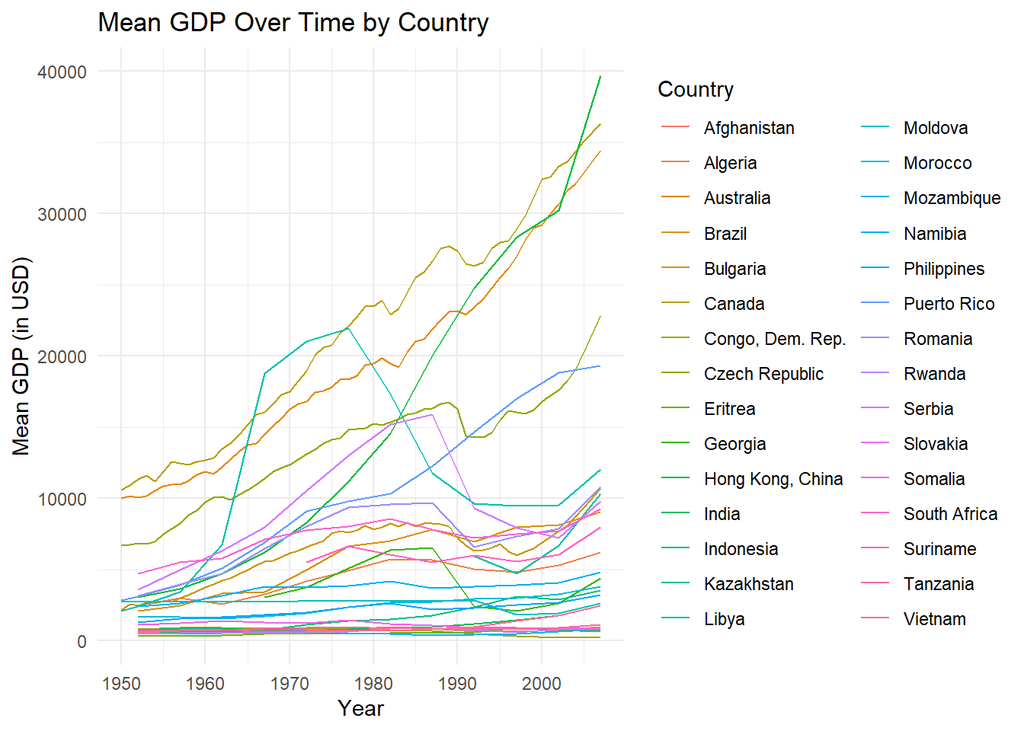

```r
ggplot(colonized_data, aes(x = year, y = gdpPercap, group = Country, color = Country))+
  geom_line()+
   labs(title = "Mean GDP Over Time by Country",
       x = "Year",
       y = "Mean GDP (in USD)") +
  theme_minimal() +                      # Minimal theme for a clean look
  theme(legend.position = "right")
```

# Measure the effect of colonial power

Does it make sense to calculate GDP for all countries grouped by colonial power?

```r
colonized_data %>%
  select(Country, Colonial_Overlord) %>%
  distinct(Country, Colonial_Overlord)
```

```
##             Country Colonial_Overlord
## 1             India    United Kingdom
## 2         Australia    United Kingdom
## 3  Hong Kong, China    United Kingdom
## 4            Canada    United Kingdom
## 5      South Africa    United Kingdom
## 6           Algeria            France
## 7           Vietnam            France
## 8           Morocco            France
## 9            Brazil          Portugal
## 10       Mozambique          Portugal
## 11        Indonesia       Netherlands
## 12         Suriname       Netherlands
## 13 Congo, Dem. Rep.           Belgium
## 14           Rwanda           Belgium
```

[output cut: 16 more lines]

```r
colonized_summary <- colonized_data %>%
  filter(year %in% unique(gapminder$year)) %>%
  group_by(Colonial_Overlord, year) %>%
  summarize(gdpPerGroup = sum(gdpPercap))
```

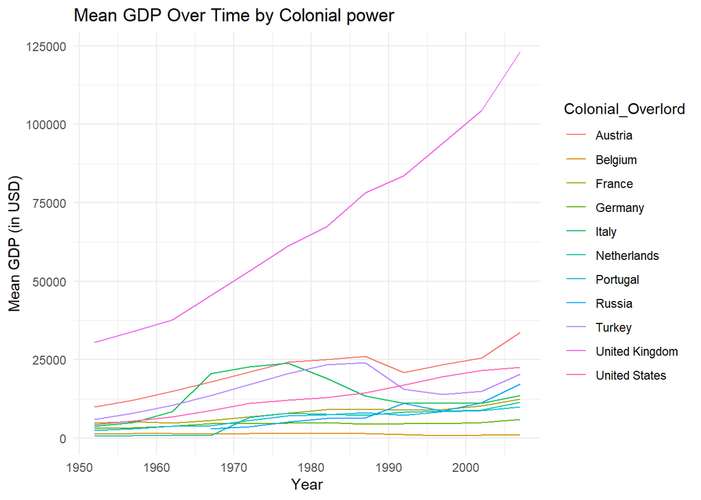

```r
ggplot(colonized_summary, aes(x = year, y = gdpPerGroup, group = Colonial_Overlord, color = Colonial_Overlord))+
  geom_line()+
   labs(title = "Mean GDP Over Time by Colonial power",
       x = "Year",
       y = "Mean GDP (in USD)") +
  theme_minimal() +                      # Minimal theme for a clean look
  theme(legend.position = "right")
```

What’s going on with the steps in 1982, 1987, in some of the groups?

```r
colonized_data %>%
  filter(Colonial_Overlord == "United Kingdom") %>%
  filter(year == 1982 |year == 1983 | year == 1987| year == 1988) %>%
  arrange(year)
```

```
##             Country Colonial_Overlord Years_of_Colonization continent year
## 1             India    United Kingdom                   190      Asia 1982
## 2         Australia    United Kingdom                   132   Oceania 1982
## 3  Hong Kong, China    United Kingdom                   156      Asia 1982
## 4            Canada    United Kingdom                   108  Americas 1982
## 5      South Africa    United Kingdom                   120    Africa 1982
## 6       Afghanistan    United Kingdom                    80      Asia 1982
## 7         Australia    United Kingdom                   132   Oceania 1983
## 8            Canada    United Kingdom                   108  Americas 1983
## 9             India    United Kingdom                   190      Asia 1987
## 10        Australia    United Kingdom                   132   Oceania 1987
## 11 Hong Kong, China    United Kingdom                   156      Asia 1987
## 12           Canada    United Kingdom                   108  Americas 1987
## 13     South Africa    United Kingdom                   120    Africa 1987
## 14      Afghanistan    United Kingdom                    80      Asia 1987
```

[output cut: 19 more lines]

```r
# years xxx3 and xxx8 seems the problematic ones in the UK case, but others are in the other countries. Use gapminder reduced data years, those seem to exist everywhere?
```

# Who is the best and worst colonial master?

We summarize colonies by their masters and then log their summed gdp to see the difference in development in the last 50 years.

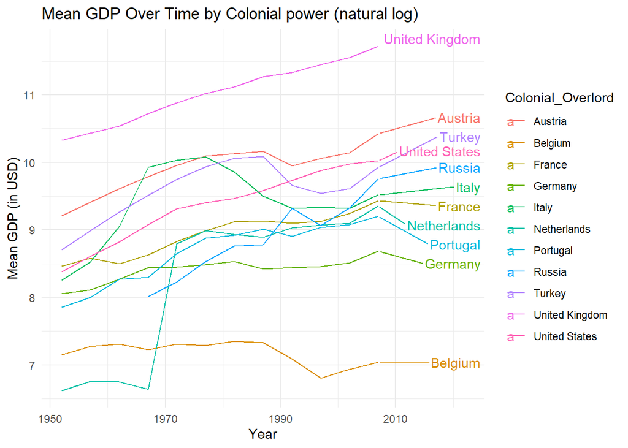

```r
# Load required libraries
library(ggplot2)
library(ggrepel)
# Assuming your data frame is 'colonized_data'

colonized_summary <- colonized_data %>%
  filter(year %in% unique(gapminder$year)) %>%
  #filter(!grepl("3$|8$", year)) %>%
  group_by(Colonial_Overlord, year) %>%
  summarize(gdpPerGroup = sum(gdpPercap))
# Find the last year for each country to label
last_year_data <- colonized_summary %>%
  group_by(Colonial_Overlord) %>%
  filter(year == max(year))  # Get the data for the last year per country

# Create the plot

ggplot(colonized_summary, aes(x = year, y = log(gdpPerGroup), group = Colonial_Overlord, color = Colonial_Overlord))+
  geom_line()+
  geom_text_repel(data = last_year_data,      # Use the last year data for labeling
                  aes(label = Colonial_Overlord),       # Label each country at the last data point
                  nudge_x = 15,                # Nudges labels slightly to the right for clarity
                  direction = "y",            # Keep labels vertical
                  hjust = 0) +                # Align the labels horizontally to the left
   labs(title = "Mean GDP Over Time by Colonial power (natural log)",
       x = "Year",
       y = "Mean GDP (in USD)") +
  theme_minimal()  #+                     # Minimal theme for a clean look
```

```r
  #theme(legend.position = "none")             # Hide the legend since we have direct labels
```

Most colonial regimes ended after WW2, so let’s look at the effect in 30 years

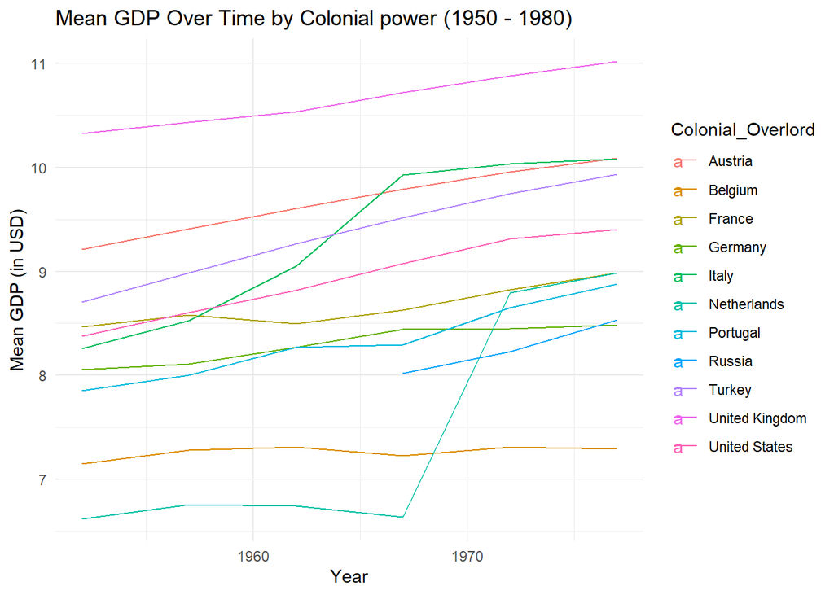

```r
# Find the last year for each country to label
last_year_data <- colonized_summary %>%
  group_by(Colonial_Overlord) %>%
  filter(year == 1980)  # Get the data for the last year per country


ggplot(colonized_summary %>% filter(year < 1980), aes(x = year, y = log(gdpPerGroup), group = Colonial_Overlord, color = Colonial_Overlord))+
  geom_line()+
  geom_text_repel(data = last_year_data,      # Use the last year data for labeling
                  aes(label = Colonial_Overlord),       # Label each country at the last data point
                  nudge_x = 15,                # Nudges labels slightly to the right for clarity
                  direction = "y",            # Keep labels vertical
                  hjust = 0) +                # Align the labels horizontally to the left
   labs(title = "Mean GDP Over Time by Colonial power (1950 - 1980)",
       x = "Year",
       y = "Mean GDP (in USD)") +
  theme_minimal()
```

# What is the situation with the *not-colonized* counterparts?

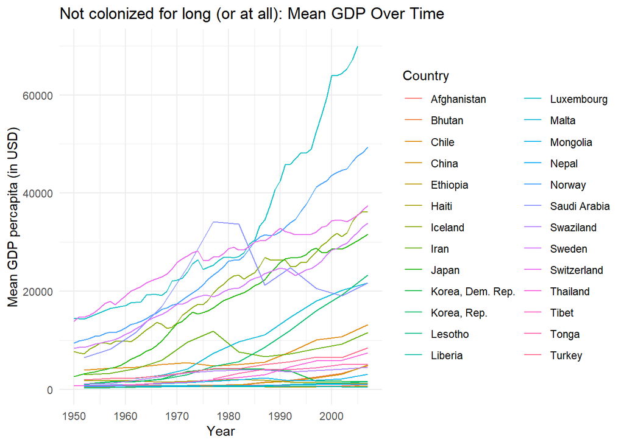

```r
# let's check their results
ggplot(not_colonized_data, aes(x = year, y = gdpPercap, group = Country, color = Country))+
  geom_line()+
  # geom_text_repel(data = last_year_data,      # Use the last year data for labeling
  #                 aes(label = Colonial_Overlord),       # Label each country at the last data point
  #                 nudge_x = 15,                # Nudges labels slightly to the right for clarity
  #                 direction = "y",            # Keep labels vertical
  #                 hjust = 0) +                # Align the labels horizontally to the left
   labs(title = "Not colonized for long (or at all): Mean GDP Over Time",
       x = "Year",
       y = "Mean GDP percapita (in USD)") +
  theme_minimal()
```

It is hard to see which country is which, so let’s add some labels. Expand the graph at the end, so as to see the lines and labels clearly.

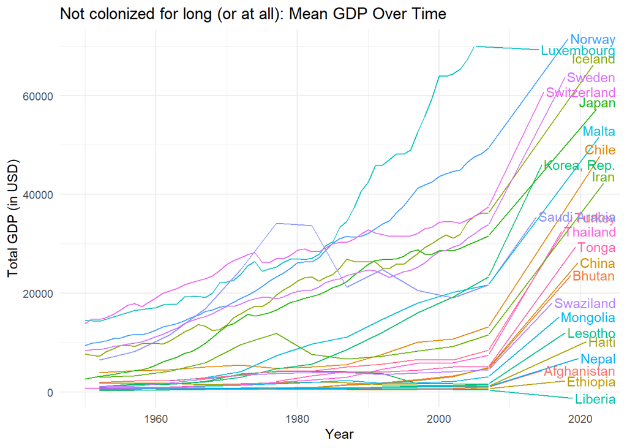

```r
nc_last_year_data <- not_colonized_data %>%
  group_by(Country) %>%
  filter(year == max(year))  # Get the data for the last year per country


# Expand this chart once it plots as it is rather detailed
not_colonized_data %>%
  ggplot(aes(x = year, y = gdpPercap, group = Country, color = Country))+
  geom_line()+
  geom_text_repel(data = nc_last_year_data,      # Use the last year data for labeling
                  aes(label = Country),       # Label each country at the last data point
                  nudge_x = 15,                # Nudges labels slightly to the right for clarity
                  direction = "y",            # Keep labels vertical
                  hjust = 0) +                # Align the labels horizontally to the left
   labs(title = "Not colonized for long (or at all): Mean GDP Over Time",
       x = "Year",
       y = "Total GDP (in USD)") +
  theme_minimal() +
  theme(legend.position = "none")
```

# Does “not being a colony” guarantee affluence?

Explore the bottom members of the not-colonized company. Create percentiles of wealth and group not-colonized countries by them. Who is at the bottom. How deep is the bottom compared to the worst-off colonies?

```r
not_colonized_data <- not_colonized_data %>%
  mutate(totalGdp = pop * gdpPercap)

# Consider whether we should be summarizing total or per capita GDP
not_colonized_ntiles <- not_colonized_data %>%
  filter(year %in% unique(gapminder$year)) %>%
  group_by(year) %>%
  mutate(quantileGdp = ntile(gdpPercap, 5))

not_colonized_summary <- not_colonized_ntiles %>%
  group_by(year, quantileGdp) %>%
    summarize(gdpPerGroup = sum(gdpPercap),
              meangdpPerGroup = mean(gdpPercap))
not_colonized_ntiles
```

```
## # A tibble: 288 × 9
## # Groups:   year [12]
##    Country Reasonably_Prosperous continent  year lifeExp       pop gdpPercap
##    <chr>   <chr>                 <fct>     <int>   <dbl>     <int>     <dbl>
##  1 Japan   YES                   Asia       1952    63.0  86459025     3217.
##  2 Japan   YES                   Asia       1957    65.5  91563009     4318.
##  3 Japan   YES                   Asia       1962    68.7  95831757     6577.
##  4 Japan   YES                   Asia       1967    71.4 100825279     9848.
##  5 Japan   YES                   Asia       1972    73.4 107188273    14779.
##  6 Japan   YES                   Asia       1977    75.4 113872473    16610.
##  7 Japan   YES                   Asia       1982    77.1 118454974    19384.
##  8 Japan   YES                   Asia       1987    78.7 122091325    22376.
##  9 Japan   YES                   Asia       1992    79.4 124329269    26825.
## 10 Japan   YES                   Asia       1997    80.7 125956499    28817.
## # ℹ 278 more rows
## # ℹ 2 more variables: totalGdp <dbl>, quantileGdp <int>
```

```r
# Find the last year for each country to label
ntile_last_year_data <- not_colonized_ntiles %>%
  group_by(quantileGdp) %>%
  filter(year == max(year)) %>%
  summarize(gdpPerGroup = sum(gdpPercap)) # Get the data for the last year per country
```

Let’s log the y-axis so we spread the data and can better see the differences in orders of magnitude.

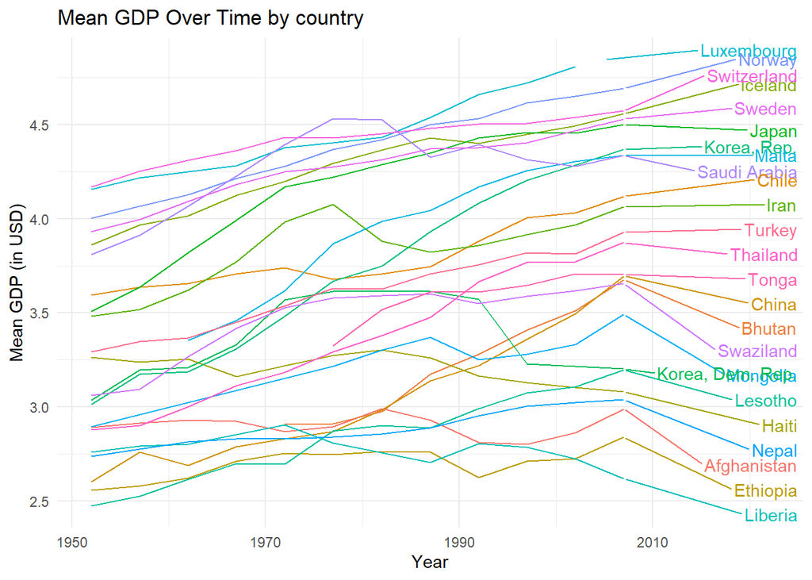

```r
# Logarithmic y axis!
ggplot(not_colonized_ntiles, aes(x = year, y = log10(gdpPercap), group = Country, color = Country))+
  geom_line()+
  geom_text_repel(data = nc_last_year_data,      # Use the last year data for labeling
                  aes(label = Country),       # Label each country at the last data point
                  nudge_x = 15,                # Nudges labels slightly to the right for clarity
                  direction = "y",            # Keep labels vertical
                  hjust = 0) +                # Align the labels horizontally to the left
   labs(title = "Mean GDP Over Time by country",
       x = "Year",
       y = "Mean GDP (in USD)") +
  theme_minimal() +
  theme(legend.position = "none")
```

We can also group countries by GDP into quantiles (exactly 5 groupings from the poorest to the richest) and plot these. It is not super meaningful chart, but exploring who is in which group at the start and the end does point to countries’ varied economic (and political) fortunes.

```r
not_colonized_ntiles
```

```
## # A tibble: 288 × 9
## # Groups:   year [12]
##    Country Reasonably_Prosperous continent  year lifeExp       pop gdpPercap
##    <chr>   <chr>                 <fct>     <int>   <dbl>     <int>     <dbl>
##  1 Japan   YES                   Asia       1952    63.0  86459025     3217.
##  2 Japan   YES                   Asia       1957    65.5  91563009     4318.
##  3 Japan   YES                   Asia       1962    68.7  95831757     6577.
##  4 Japan   YES                   Asia       1967    71.4 100825279     9848.
##  5 Japan   YES                   Asia       1972    73.4 107188273    14779.
##  6 Japan   YES                   Asia       1977    75.4 113872473    16610.
##  7 Japan   YES                   Asia       1982    77.1 118454974    19384.
##  8 Japan   YES                   Asia       1987    78.7 122091325    22376.
##  9 Japan   YES                   Asia       1992    79.4 124329269    26825.
## 10 Japan   YES                   Asia       1997    80.7 125956499    28817.
## # ℹ 278 more rows
## # ℹ 2 more variables: totalGdp <dbl>, quantileGdp <int>
```

```r
# How are the best and worst countries moving economically over the last 60 years?
not_colonized_summary <- not_colonized_ntiles %>%
    arrange(desc(year)) %>%
    group_by(year, quantileGdp) %>%
    summarize(gdpPerGroup = sum(gdpPercap),
              meangdpPerGroup = mean(gdpPercap)) %>%
   mutate(quantileGdp = as.factor(quantileGdp))
not_colonized_summary
```

```
## # A tibble: 60 × 4
## # Groups:   year [12]
##     year quantileGdp gdpPerGroup meangdpPerGroup
##    <int> <fct>             <dbl>           <dbl>
##  1  1952 1                 2183.            437.
##  2  1952 2                 4443.            889.
##  3  1952 3                 7993.           1998.
##  4  1952 4                20884.           5221.
##  5  1952 5                47684.          11921.
##  6  1957 1                 2510.            502.
##  7  1957 2                 5259.           1052.
##  8  1957 3                 8807.           2202.
##  9  1957 4                26035.           6509.
## 10  1957 5                56021.          14005.
## # ℹ 50 more rows
```

```r
# Extract data for the last year to use in geom_text_repel
ntile_last_year_data <- not_colonized_summary %>%
  group_by(quantileGdp) %>%
  filter(year == max(year))  # Extract the last year for each quantile
ntile_last_year_data
```

```
## # A tibble: 5 × 4
## # Groups:   quantileGdp [5]
##    year quantileGdp gdpPerGroup meangdpPerGroup
##   <int> <fct>             <dbl>           <dbl>
## 1  2007 1                 4373.            875.
## 2  2007 2                15516.           3103.
## 3  2007 3                37545.           7509.
## 4  2007 4               111542.          22308.
## 5  2007 5               156904.          39226.
```

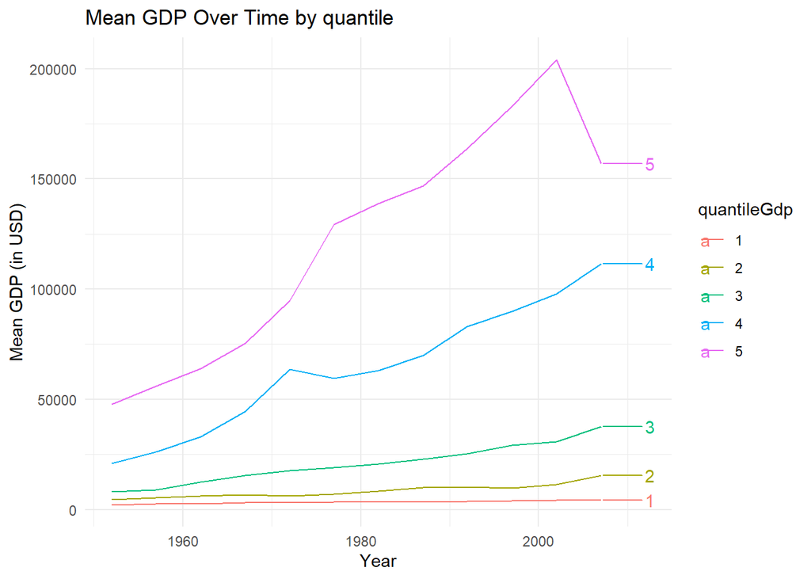

```r
ggplot(not_colonized_summary, aes(x = year, y = gdpPerGroup, group = quantileGdp, color = quantileGdp))+
  geom_line()+
  geom_text_repel(data = ntile_last_year_data,      # Use the last year data for labeling
                  aes(x = year, y = gdpPerGroup, label = quantileGdp),       # Label each country at the last data point
                  nudge_x = 5,                # Nudges labels slightly to the right for clarity
                  direction = "y",            # Keep labels vertical
                  hjust = 0) +                # Align the labels horizontally to the left
   labs(title = "Mean GDP Over Time by quantile",
       x = "Year",
       y = "Mean GDP (in USD)") +
  theme_minimal()
```

```r
# Who is in groups 1 and 5 at the start and the end?

not_colonized_ntiles %>%
  filter(year == 1957 & quantileGdp == 5) %>%
  select(Country, gdpPercap)
```

```
## # A tibble: 4 × 3
## # Groups:   year [1]
##    year Country     gdpPercap
##   <int> <chr>           <dbl>
## 1  1957 Sweden          9912.
## 2  1957 Norway         11654.
## 3  1957 Switzerland    17909.
## 4  1957 Luxembourg     16546.
```

```r
not_colonized_ntiles %>%
  filter(year >2002 & quantileGdp == 5) %>%
  select(Country, gdpPercap)
```

```
## # A tibble: 4 × 3
## # Groups:   year [1]
##    year Country     gdpPercap
##   <int> <chr>           <dbl>
## 1  2007 Iceland        36181.
## 2  2007 Sweden         33860.
## 3  2007 Norway         49357.
## 4  2007 Switzerland    37506.
```

```r
# Where is China in all this and how does its progress compare to e.g. Saudi Arabia?
not_colonized_ntiles %>%
  filter(Country == "China") %>%
  select(year, gdpPercap, quantileGdp)
```

```
## # A tibble: 12 × 3
## # Groups:   year [12]
##     year gdpPercap quantileGdp
##    <int>     <dbl>       <int>
##  1  1952      400.           1
##  2  1957      576.           1
##  3  1962      488.           1
##  4  1967      613.           1
##  5  1972      677.           1
##  6  1977      741.           1
##  7  1982      962.           2
##  8  1987     1379.           2
##  9  1992     1656.           2
## 10  1997     2289.           2
## 11  2002     3119.           2
## 12  2007     4959.           3
```

```r
not_colonized_ntiles %>%
  filter(Country == "Saudi Arabia") %>%
  select(year, gdpPercap, quantileGdp)
```

```
## # A tibble: 12 × 3
## # Groups:   year [12]
##     year gdpPercap quantileGdp
##    <int>     <dbl>       <int>
##  1  1952     6460.           4
##  2  1957     8158.           4
##  3  1962    11626.           4
##  4  1967    16903.           5
##  5  1972    24837.           5
##  6  1977    34168.           5
##  7  1982    33693.           5
##  8  1987    21198.           4
##  9  1992    24842.           4
## 10  1997    20587.           4
## 11  2002    19015.           4
## 12  2007    21655.           4
```

```r
# Can you think of other 'climbers'?
```

# Significance testing 1: Does the colonial overlord matter?

```r
# Run a basic linear regression model
model <- lm(gdpPercap ~ Colonial_Overlord, data = colonized_data)

# Summary of the regression results
summary(model)
```

```
##
## Call:
## lm(formula = gdpPercap ~ Colonial_Overlord, data = colonized_data)
##
## Residuals:
##      Min       1Q   Median       3Q      Max
## -15693.1  -3269.8   -196.6   2633.2  23485.3
##
## Coefficients:
##                                 Estimate Std. Error t value Pr(>|t|)
## (Intercept)                      12505.2      773.0  16.177  < 2e-16 ***
## Colonial_OverlordBelgium        -11843.2     1529.8  -7.742 5.54e-14 ***
## Colonial_OverlordFrance          -9874.7     1326.4  -7.445 4.32e-13 ***
## Colonial_OverlordGermany        -10242.8     1529.8  -6.695 5.83e-11 ***
## Colonial_OverlordItaly           -8007.2     1314.5  -6.091 2.25e-09 ***
## Colonial_OverlordNetherlands     -8994.5     1639.8  -5.485 6.59e-08 ***
## Colonial_OverlordPortugal        -9319.4     1529.8  -6.092 2.24e-09 ***
## Colonial_OverlordRussia          -8293.9     1709.2  -4.853 1.63e-06 ***
## Colonial_OverlordTurkey          -5777.4     1097.1  -5.266 2.08e-07 ***
## Colonial_OverlordUnited Kingdom   3734.4      925.9   4.033 6.37e-05 ***
## Colonial_OverlordUnited States   -6134.1     1506.9  -4.071 5.45e-05 ***
## ---
## Signif. codes:  0 '***' 0.001 '**' 0.01 '*' 0.05 '.' 0.1 ' ' 1
##
## Residual standard error: 6467 on 497 degrees of freedom
##   (1 observation deleted due to missingness)
## Multiple R-squared:  0.4441, Adjusted R-squared:  0.4329
## F-statistic:  39.7 on 10 and 497 DF,  p-value: < 2.2e-16
```

### How to interpret the summary?

# Significance testing 2: Does the duration of colonialism matter?

```r
model_interaction <- lm(gdpPercap ~ Years_of_Colonization * factor(Colonial_Overlord), data = colonized_data)
summary(model_interaction)
```

```
##
## Call:
## lm(formula = gdpPercap ~ Years_of_Colonization * factor(Colonial_Overlord),
##     data = colonized_data)
##
## Residuals:
##      Min       1Q   Median       3Q      Max
## -18659.8  -2746.7     16.5   2045.6  25608.0
##
## Coefficients: (2 not defined because of singularities)
##                                                                Estimate
## (Intercept)                                                   -18532.64
## Years_of_Colonization                                            103.46
## factor(Colonial_Overlord)Belgium                               19235.64
## factor(Colonial_Overlord)France                                18812.39
## factor(Colonial_Overlord)Germany                               33199.39
## factor(Colonial_Overlord)Italy                                 33551.52
## factor(Colonial_Overlord)Netherlands                           33736.53
## factor(Colonial_Overlord)Portugal                              35345.35
## factor(Colonial_Overlord)Russia                                19367.26
## factor(Colonial_Overlord)Turkey                               -10950.34
## factor(Colonial_Overlord)United Kingdom                        43278.44
## factor(Colonial_Overlord)United States                         15741.35
## Years_of_Colonization:factor(Colonial_Overlord)Belgium          -104.14
## Years_of_Colonization:factor(Colonial_Overlord)France            -74.44
## Years_of_Colonization:factor(Colonial_Overlord)Germany          -417.49
## Years_of_Colonization:factor(Colonial_Overlord)Italy            -349.99
## Years_of_Colonization:factor(Colonial_Overlord)Netherlands      -141.92
## Years_of_Colonization:factor(Colonial_Overlord)Portugal         -137.57
## Years_of_Colonization:factor(Colonial_Overlord)Russia            -79.02
## Years_of_Colonization:factor(Colonial_Overlord)Turkey                NA
## Years_of_Colonization:factor(Colonial_Overlord)United Kingdom   -171.59
## Years_of_Colonization:factor(Colonial_Overlord)United States         NA
##                                                               Std. Error
## (Intercept)                                                      9658.21
## Years_of_Colonization                                              32.10
## factor(Colonial_Overlord)Belgium                                10467.95
## factor(Colonial_Overlord)France                                  9975.00
## factor(Colonial_Overlord)Germany                                14848.47
## factor(Colonial_Overlord)Italy                                  10238.74
```

[output cut: 54 more lines]

```
## Years_of_Colonization:factor(Colonial_Overlord)Germany
## Years_of_Colonization:factor(Colonial_Overlord)Italy          ***
## Years_of_Colonization:factor(Colonial_Overlord)Netherlands    ***
## Years_of_Colonization:factor(Colonial_Overlord)Portugal       ***
## Years_of_Colonization:factor(Colonial_Overlord)Russia         .
## Years_of_Colonization:factor(Colonial_Overlord)Turkey
## Years_of_Colonization:factor(Colonial_Overlord)United Kingdom ***
## Years_of_Colonization:factor(Colonial_Overlord)United States
## ---
## Signif. codes:  0 '***' 0.001 '**' 0.01 '*' 0.05 '.' 0.1 ' ' 1
##
## Residual standard error: 6254 on 488 degrees of freedom
##   (1 observation deleted due to missingness)
## Multiple R-squared:  0.4896, Adjusted R-squared:  0.4697
## F-statistic: 24.63 on 19 and 488 DF,  p-value: < 2.2e-16
```

### How do you interpret this model summary?

- Colonial Duration: This coefficient shows the general effect of an additional year of colonization across all colonial powers, assuming no interaction.
- Colonial Overlord: This coefficient shows the effect of the specific colonial power, assuming no interaction with the duration.
- Interaction Term: The interaction term measures how the effect of each additional year of colonization differs depending on the colonial overlord.

Significance codes tell you if the different could have arisen by chance or not? 0 = no chance, 1 = all chance R-squared amount tells you how much of the data is explained by this model. 1 = 100%. If below 1, other factors are in play. In our case, consider existing regimes (dictator ship, socialist episode, starting development level etc.)

# Visualize the model results

```r
# Extract model coefficients
coefficients <- as.data.frame(coef(summary(model_interaction)))

# Create a column for variable names
coefficients$Variable <- rownames(coefficients)

# Split into main effects (Colonial_Overlord) and interaction terms (Colonial_Overlord × Year)
main_effects <- coefficients %>%
  filter(grepl("Colonial_Overlord", Variable) & !grepl(":", Variable)) %>%  # Only colonial overlord effects
  mutate(Country = sub(".*factor\\(Colonial_Overlord\\)", "", Variable))  # Extract the country name

interaction_effects <- coefficients %>%
  filter(grepl("Colonial_Overlord", Variable) & grepl(":", Variable)) #%>%    # Only interaction terms

interaction_effects_clean <- interaction_effects %>%
  mutate(Country = sub(".*factor\\(Colonial_Overlord\\)", "", Variable))  # Extract the country name

options(scipen = 999)
```

## Plot 1: Main Effects of Colonial Overlord

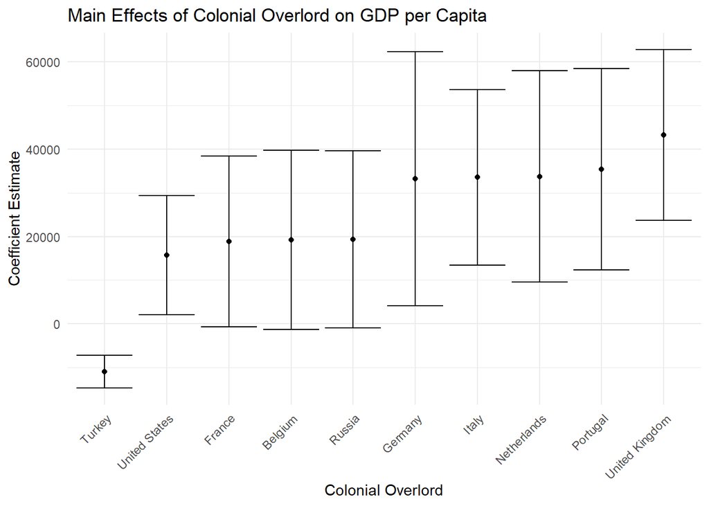

```r
# Plot 1: Main Effects of Colonial Overlord
plot1 <- ggplot(main_effects, aes(x = reorder(Country, Estimate), y = Estimate)) +
  geom_point() +
  geom_errorbar(aes(ymin = Estimate - 1.96 * `Std. Error`, ymax = Estimate + 1.96 * `Std. Error`)) +
  labs(title = "Main Effects of Colonial Overlord on GDP per Capita",
       x = "Colonial Overlord",
       y = "Coefficient Estimate") +
  theme_minimal() +
  theme(axis.text.x = element_text(angle = 45, hjust = 1))  # Rotate x-axis labels
plot1
```

## Plot 2: Interaction Effects of Colonial Overlord × Year on GDP per Capita

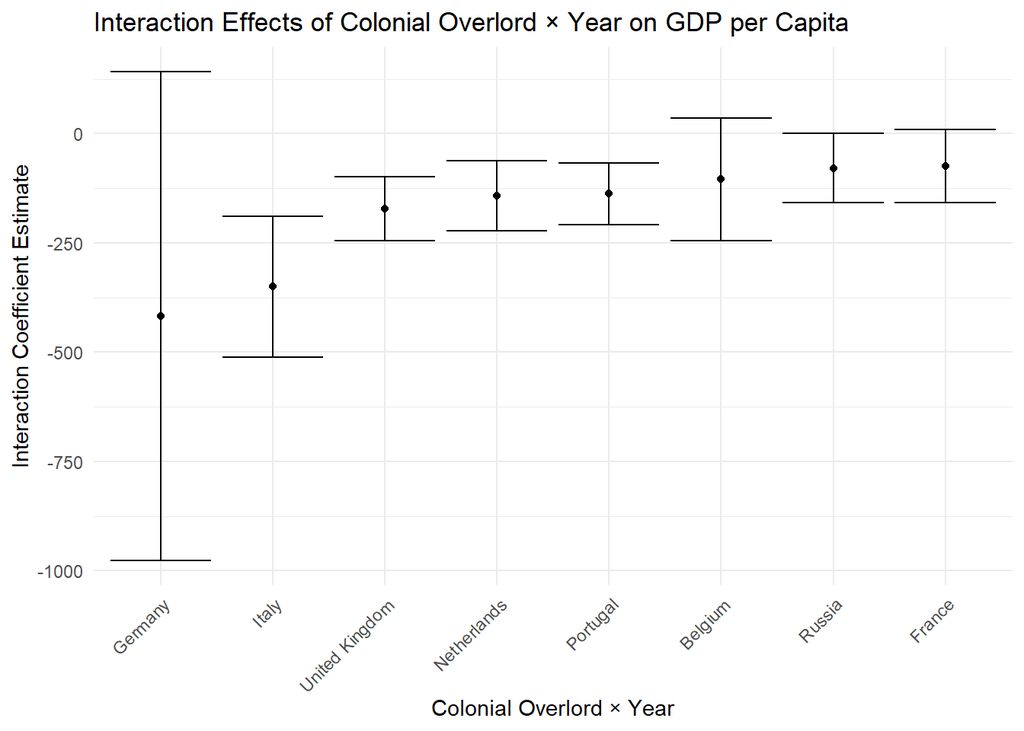

```r
# Plot 2: Interaction Effects of Colonial Overlord × Year on GDP per Capita
plot2 <- ggplot(interaction_effects_clean, aes(x = reorder(Country, Estimate), y = Estimate)) +
  geom_point() +
  geom_errorbar(aes(ymin = Estimate - 1.96 * `Std. Error`, ymax = Estimate + 1.96 * `Std. Error`)) +
  labs(title = "Interaction Effects of Colonial Overlord × Year on GDP per Capita",
       x = "Colonial Overlord × Year",
       y = "Interaction Coefficient Estimate") +
  theme_minimal() +
  theme(axis.text.x = element_text(angle = 45, hjust = 1))
plot2
```

## Hints:

### If you wish to combine two or more plots

.. you need to first write them into objects and then combine using the `patchwork` library. Choose more meaningful names than `plot1` and `plot2`, please ;).

```r
install.packages("patchwork")
library(patchwork) # you will need to install it first

plot1 + plot2
```

### How is rate of change affected?

```r
#let's define a function for percent change

pctchange <-function(x) {
 pct <- 100*((x - lag(x))/(lag(x)))
 return (pct)
}
```

## Possible expansions:

1. Investigate closely two opposite cases (e.g. Liberia, Ethiopia) and delve into their colonial background. An empire for 300 years or 3 years under an aggressive inexperienced wanna-be-colonist?
2. Recode the table on how long it is *since colonialism*. How much effect is there?
3. Change the focus from Colonialism to political establishment. Add data on ‘Duration_socialism’, or ‘Duration_dictatorship’ for the last 100 years and check their effect. (Check the Varieties of Democracy project if you need more input https://v-dem.net/ )

# Evaluation

After this initial bout of visualisations and tests, it is time to summarize your findings and reflect on them as well as the whole process of analysis.

1. Consider the pipeline from the beginning: by what criteria did you selected your (un-) colonized countries and colonizers? What biases / intent shaped your interpretations and thereby your results? What considerations or rules did you implement when encoding the ‘victims’ and ‘perpetrators’? Are other interpretations possible and do they significantly change the results?
2. Next, what sense do you make of the linear regressions? What significant outcomes do you see and how do you understand their visual outputs? Explain the meaning of the lm results, underscore the lessons learnt.
3. Describe the visualisations to the reader: what should the reader notice and how should she understand the various log and other y axis values, the trendlines, groupings, and their colors etc.? Remember that data don’t speak for themselves. What do we see?
4. Document the code so that each chunk has a rationale and an explanation. Beautify and explain concisely.
5. Finally, reflect on what lessons do you think this sort of analysis offers to the historian?’’

```r
colonized_data2 <- select(colonized_data, Country, Years_of_Colonization, year, gdpPercap)

colonized_data2
```

```
##              Country Years_of_Colonization year  gdpPercap
## 1              India                   190 1952   546.5657
## 2              India                   190 1957   590.0620
## 3              India                   190 1962   658.3472
## 4              India                   190 1967   700.7706
## 5              India                   190 1972   724.0325
## 6              India                   190 1977   813.3373
## 7              India                   190 1982   855.7235
## 8              India                   190 1987   976.5127
## 9              India                   190 1992  1164.4068
## 10             India                   190 1997  1458.8174
## 11             India                   190 2002  1746.7695
## 12             India                   190 2007  2452.2104
## 13         Australia                   132 1950 10031.1214
## 14         Australia                   132 1951 10160.7367
```

[output cut: 495 more lines]

```r
plus100years <- c("India", "Australia", "Hong Kong", "Canada", "South Africa", "Algeria", "Brazil", "Mozambique", "Indonesia", "Suriname", "Puerto Rico", "Kazakhstan", "Georgia", "Moldova", "Czech Republic", "Slovakia", "Romania", "Serbia", "Bulgaria")



under100years <- c("Vietnam", "Morocco", "Congo, Dem Rep.", "Rwanda", "Namibia", "Somalia", "Libya", "Eritrea", "Philippines", "Afghanistan", "Tanzania")


under100years
```

```
##  [1] "Vietnam"         "Morocco"         "Congo, Dem Rep." "Rwanda"
##  [5] "Namibia"         "Somalia"         "Libya"           "Eritrea"
##  [9] "Philippines"     "Afghanistan"     "Tanzania"
```

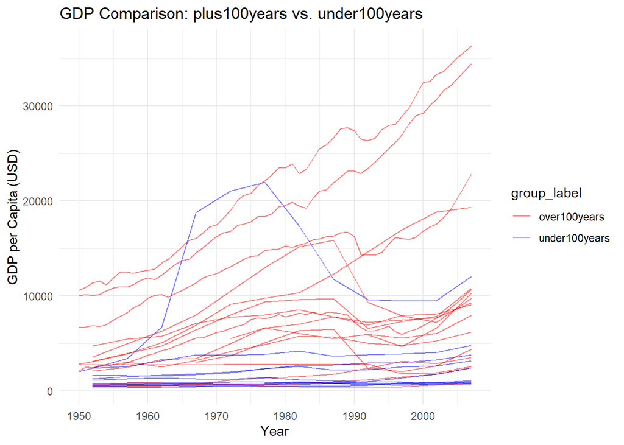

```r
library("ggplot2")
library("dplyr")


gapminder_unfiltered <- gapminder_unfiltered %>%
  mutate(group_label = case_when(
    country %in% plus100years ~ "over100years",
    country %in% under100years ~ "under100years")) %>%
  filter(!is.na(group_label))

ggplot(gapminder_unfiltered, aes(x = year, y = gdpPercap, group = country)) +
  geom_line(aes(color = group_label), alpha = 0.5) +
  labs(title = "GDP Comparison: plus100years vs. under100years",
       x = "Year", y = "GDP per Capita (USD)") +
  theme_minimal() +
  theme(legend.position = "right") +
  scale_color_manual(values = c("over100years" = "red", "under100years" = "blue"))
```